# Assignment 3

## Objectives of This Analysis

- First, I decided it would be interesting to look at the initial charges, themselves, to see if different groups tend to be charged with higher or lower class felonies from the beginning. Such differences might reflect biases in policing or in the early stages of prosecution, or could just be the result of different classes of people committing different crimes at different rates.
- My main goal was to analyze the generosity or fairness of the Cook County Attorney's office over the years. I created a dependent variable I called *felony_class_difference* and set equal to the change in felony class from arraignment to disposition for each defendant. I think this is an imperfect measure of fairness, but it is the best I could find from the data as it exists today. I then looked at how the independent variables *race, gender and age* impact the felony_class_difference to see if there appears to be any systematic bias for or against any particular groups.

## Part 1: Reading in and exploring the initiation data

```python
import numpy as np
import pandas as pd
import matplotlib.pyplot as plt
import seaborn as sns
from matplotlib.pyplot import figure
%matplotlib inline
import warnings
sns.set(style="darkgrid")
warnings.filterwarnings('ignore')
import datetime
```

```python
initiation = pd.read_csv('Initiation.csv', low_memory=False)
```

```python
initiation.head()
```

|  | CASE_ID | CASE_PARTICIPANT_ID | PRIMARY_CHARGE | CHARGE_ID | CHARGE_VERSION_ID | CHAPTER | ACT | SECTION | CLASS | AOIC | ... | INCIDENT_END_DATE | ARREST_DATE | LAW_ENFORCEMENT_AGENCY | UNIT | INCIDENT_CITY | RECEIVED_DATE | ARRAIGNMENT_DATE | UPDATED_OFFENSE_CATEGORY | CHARGE_OFFENSE_TITLE | CHARGE_COUNT |
| --- | --- | --- | --- | --- | --- | --- | --- | --- | --- | --- | --- | --- | --- | --- | --- | --- | --- | --- | --- | --- | --- |
| 0 | 89636659845 | 135342759273 | False | 563965111550 | 487780942354 | 720 | 5 | 9-1(a)(2) | M | 0735100 | ... | NaN | 5/22/2011 6:51:00 PM | PROMIS Data Conversion | NaN | NaN | 5/24/2011 12:00:00 AM | 7/11/2011 12:00:00 AM | Homicide | FIRST DEGREE MURDER | 2 |
| 1 | 89636659845 | 135342759273 | False | 563966831069 | 487782428385 | 720 | 5 | 9-1(a)(3) | M | 0735200 | ... | NaN | 5/22/2011 6:51:00 PM | PROMIS Data Conversion | NaN | NaN | 5/24/2011 12:00:00 AM | 7/11/2011 12:00:00 AM | Homicide | FIRST DEGREE MURDER | 3 |
| 2 | 89636659845 | 135342759273 | False | 563968304943 | 487783772890 | 720 | 5 | 9-1(a)(3) | M | 0735200 | ... | NaN | 5/22/2011 6:51:00 PM | PROMIS Data Conversion | NaN | NaN | 5/24/2011 12:00:00 AM | 7/11/2011 12:00:00 AM | Homicide | FIRST DEGREE MURDER | 4 |
| 3 | 89636659845 | 135342759273 | False | 563968796235 | 487784197470 | 720 | 5 | 9-1(a)(3) | M | 0735200 | ... | NaN | 5/22/2011 6:51:00 PM | PROMIS Data Conversion | NaN | NaN | 5/24/2011 12:00:00 AM | 7/11/2011 12:00:00 AM | Homicide | FIRST DEGREE MURDER | 5 |
| 4 | 89636659845 | 135342759273 | False | 563969696935 | 487784975868 | 720 | 5 | 9-1(a)(3) | M | 0735200 | ... | NaN | 5/22/2011 6:51:00 PM | PROMIS Data Conversion | NaN | NaN | 5/24/2011 12:00:00 AM | 7/11/2011 12:00:00 AM | Homicide | FIRST DEGREE MURDER | 6 |

5 rows × 26 columns

```python
initiation.shape
```

```
(839181, 26)
```

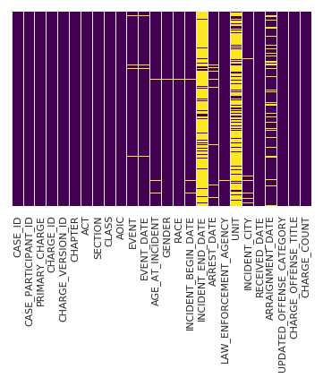

```python
sns.heatmap(initiation.isnull(),yticklabels=False,cbar=False,cmap='viridis')
```

```python
initiation.drop(['INCIDENT_END_DATE','UNIT'], axis=1, inplace=True)
```

```python
initiation.dropna(inplace=True)
```

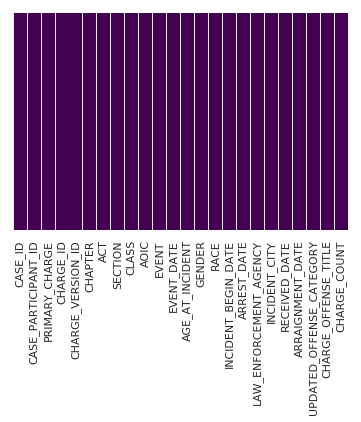

```python
sns.heatmap(initiation.isnull(),yticklabels=False,cbar=False,cmap='viridis')
```

```python
initiation['CLASS'].value_counts()
```

```
4    231874
2    169426
3    105495
X     77998
1     60931
M     26081
A       470
B        19
C        16
Z         6
P         1
Name: CLASS, dtype: int64
```

```python
initiation.columns
```

```
Index(['CASE_ID', 'CASE_PARTICIPANT_ID', 'PRIMARY_CHARGE', 'CHARGE_ID',
       'CHARGE_VERSION_ID', 'CHAPTER', 'ACT', 'SECTION', 'CLASS', 'AOIC',
       'EVENT', 'EVENT_DATE', 'AGE_AT_INCIDENT', 'GENDER', 'RACE',
       'INCIDENT_BEGIN_DATE', 'ARREST_DATE', 'LAW_ENFORCEMENT_AGENCY',
       'INCIDENT_CITY', 'RECEIVED_DATE', 'ARRAIGNMENT_DATE',
       'UPDATED_OFFENSE_CATEGORY', 'CHARGE_OFFENSE_TITLE', 'CHARGE_COUNT'],
      dtype='object')
```

```python
initiation_filtered = initiation[['CASE_PARTICIPANT_ID', 'CHARGE_ID', 'CHARGE_OFFENSE_TITLE', 'CLASS','AGE_AT_INCIDENT', 'GENDER',
            'RACE', 'LAW_ENFORCEMENT_AGENCY', 'ARRAIGNMENT_DATE', 'UPDATED_OFFENSE_CATEGORY']]
```

```python
initiation_filtered.shape
```

```
(672317, 10)
```

```python
initiation_filtered.iloc[:,-2] = initiation_filtered.iloc[:, -2].apply(pd.to_datetime, errors='coerce')
initiation_filtered['arraignment_year'] = initiation_filtered.ARRAIGNMENT_DATE.dt.year
initiation_filtered.drop('ARRAIGNMENT_DATE', axis=1, inplace=True)
initiation_filtered.head()
```

|  | CASE_PARTICIPANT_ID | CHARGE_ID | CHARGE_OFFENSE_TITLE | CLASS | AGE_AT_INCIDENT | GENDER | RACE | LAW_ENFORCEMENT_AGENCY | UPDATED_OFFENSE_CATEGORY | arraignment_year |
| --- | --- | --- | --- | --- | --- | --- | --- | --- | --- | --- |
| 116 | 459015687748 | 555449231356 | [POSSESSION OF CONTROLLED SUBSTANCE WITH INTEN... | X | 34.0 | Male | Black | CHICAGO PD | Narcotics | 2011.0 |
| 117 | 459015687748 | 556334538337 | ARMED HABITUAL CRIMINAL | X | 34.0 | Male | Black | CHICAGO PD | Narcotics | 2011.0 |
| 118 | 459015687748 | 556335439038 | ARMED VIOLENCE | X | 34.0 | Male | Black | CHICAGO PD | Narcotics | 2011.0 |
| 119 | 459015687748 | 555347861578 | UNLAWFUL USE OR POSSESSION OF A WEAPON BY A FELON | 2 | 34.0 | Male | Black | CHICAGO PD | Narcotics | 2011.0 |
| 120 | 459015687748 | 556336339739 | AGGRAVATED UNLAWFUL USE OF WEAPON | 2 | 34.0 | Male | Black | CHICAGO PD | Narcotics | 2011.0 |

```python
initiation_filtered.rename(columns={'CASE_PARTICIPANT_ID':'participant_id', 'CHARGE_ID':'charge_id','CHARGE_OFFENSE_TITLE':'charge_offence_title',
                                    'CLASS':'felony_class_initiation', 'AGE_AT_INCIDENT':'age','GENDER':'gender','RACE':'race',
                                    'LAW_ENFORCEMENT_AGENCY':'law_enforcement_agency', 'UPDATED_OFFENSE_CATEGORY':'updated_offense_category'}, inplace=True)
```

```python
initiation_filtered.head()
```

|  | participant_id | charge_id | charge_offence_title | felony_class_initiation | age | gender | race | law_enforcement_agency | updated_offense_category | arraignment_year |
| --- | --- | --- | --- | --- | --- | --- | --- | --- | --- | --- |
| 116 | 459015687748 | 555449231356 | [POSSESSION OF CONTROLLED SUBSTANCE WITH INTEN... | X | 34.0 | Male | Black | CHICAGO PD | Narcotics | 2011.0 |
| 117 | 459015687748 | 556334538337 | ARMED HABITUAL CRIMINAL | X | 34.0 | Male | Black | CHICAGO PD | Narcotics | 2011.0 |
| 118 | 459015687748 | 556335439038 | ARMED VIOLENCE | X | 34.0 | Male | Black | CHICAGO PD | Narcotics | 2011.0 |
| 119 | 459015687748 | 555347861578 | UNLAWFUL USE OR POSSESSION OF A WEAPON BY A FELON | 2 | 34.0 | Male | Black | CHICAGO PD | Narcotics | 2011.0 |
| 120 | 459015687748 | 556336339739 | AGGRAVATED UNLAWFUL USE OF WEAPON | 2 | 34.0 | Male | Black | CHICAGO PD | Narcotics | 2011.0 |

```python
initiation_filtered = initiation_filtered[initiation_filtered['felony_class_initiation'].isin(['X','1','2','3','4'])]
```

```python
initiation_filtered['felony_class_initiation'] = initiation_filtered['felony_class_initiation'].map({'X': 0,'1': 1,'2':2,'3':3, '4':4})
```

```python
initiation_filtered.race.value_counts()
```

```
Black                               434531
White [Hispanic or Latino]          116875
White                                78699
HISPANIC                              6653
Asian                                 4496
White/Black [Hispanic or Latino]      3232
Unknown                                853
American Indian                        306
Biracial                                73
ASIAN                                    6
Name: race, dtype: int64
```

```python
initiation_filtered['race'] = initiation_filtered['race'].str.lower()
```

```python
initiation_filtered.race.value_counts()
```

```
black                               434531
white [hispanic or latino]          116875
white                                78699
hispanic                              6653
asian                                 4502
white/black [hispanic or latino]      3232
unknown                                853
american indian                        306
biracial                                73
Name: race, dtype: int64
```

```python
initiation_filtered = initiation_filtered[initiation_filtered['race'].isin(['black',
                    'white [hispanic or latino] ', 'white', 'hispanic','asian',
                    'white/black [hispanic or latino]'])]
```

```python
initiation_filtered.gender.value_counts()
```

```
Male                          471365
Female                         56239
Unknown                            6
Male name, no gender given         5
Unknown Gender                     2
Name: gender, dtype: int64
```

```python
initiation_filtered = initiation_filtered[initiation_filtered['gender'].isin(['Male', 'Female'])]
```

## Data Visualization

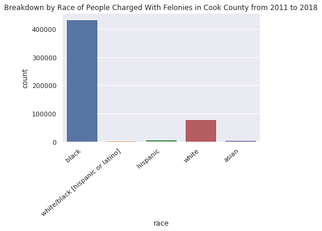

```python
ax = sns.countplot(initiation_filtered['race'])

ax.set_xticklabels(ax.get_xticklabels(), rotation=40, ha="right")

ax.set_title('Breakdown by Race of People Charged With Felonies in Cook County from 2011 to 2018')
plt.show()
```

#### Observation: Black people comprised more than 2/3 of all people charged with felonies during this time period.

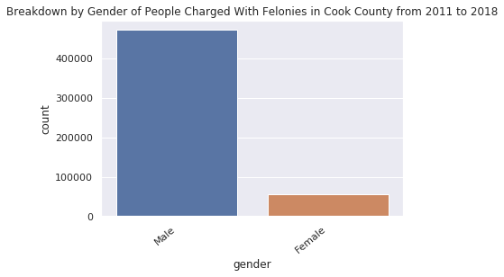

```python
ax = sns.countplot(initiation_filtered['gender'])

ax.set_xticklabels(ax.get_xticklabels(), rotation=40, ha="right")

ax.set_title('Breakdown by Gender of People Charged With Felonies in Cook County from 2011 to 2018')
plt.show()
```

*Note: I included only Male and Female gender because the data for other categories of gender is insufficient.*

```python
initiation_filtered[['age','arraignment_year']]  = initiation_filtered[['age','arraignment_year']].fillna(0.0).astype(int)
```

```python
initiation_filtered.arraignment_year.value_counts()
```

```
2012    70439
2013    69370
2018    64869
2014    64215
2017    63898
2015    62610
2016    62520
2011    60096
2019     9534
2010       25
2106        6
2007        6
2001        4
2103        3
0           3
2008        2
2108        1
2117        1
1985        1
2100        1
Name: arraignment_year, dtype: int64
```

*I decided to work with data between 2011 and 2018 only because the data for the other years is incomplete.*

```python
initiation_filtered = initiation_filtered[(initiation_filtered['arraignment_year'] > 2010) & (initiation_filtered['arraignment_year'] < 2019)]
```

```python
initiation_filtered.arraignment_year.value_counts()
```

```
2012    70439
2013    69370
2018    64869
2014    64215
2017    63898
2015    62610
2016    62520
2011    60096
Name: arraignment_year, dtype: int64
```

```python
multi_plot = initiation_filtered.groupby(['arraignment_year', 'race']).felony_class_initiation.mean()
multi_plot = multi_plot.unstack()
multi_plot
```

| race arraignment_year | asian | black | hispanic | white | white/black [hispanic or latino] |
| --- | --- | --- | --- | --- | --- |
| 2011 | 2.587336 | 2.508401 | 3.224401 | 2.668670 | 2.439678 |
| 2012 | 2.582367 | 2.516357 | 3.472013 | 2.840857 | 2.626039 |
| 2013 | 2.445000 | 2.373637 | 3.539157 | 2.779796 | 2.287982 |
| 2014 | 2.219259 | 2.363948 | 3.525786 | 2.806799 | 2.478261 |
| 2015 | 2.296562 | 2.429692 | 3.651189 | 2.759598 | 2.723039 |
| 2016 | 2.596262 | 2.442053 | 3.617702 | 2.731924 | 2.219858 |
| 2017 | 2.685921 | 2.434579 | 3.646199 | 2.637439 | 2.529680 |
| 2018 | 2.642105 | 2.519948 | 3.688889 | 2.790099 | 2.591479 |

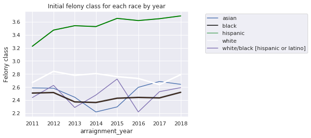

```python
multi_plot.loc[:, :].plot()
plt.legend(bbox_to_anchor=(1.75, 1), loc='upper right',  ncol=1)


plt.plot(multi_plot['black'], marker='', color='black', linewidth=3, alpha=0.7)
plt.plot(multi_plot['white'], marker='', color='white', linewidth=3, alpha=1)
plt.plot(multi_plot['hispanic'], marker='', color='green', linewidth=2, alpha=1)

ax = plt.gca()
leg = ax.get_legend()
leg.legendHandles[1].set_color('black')
leg.legendHandles[3].set_color('white')

plt.ylabel('Felony class')
plt.title('Initial felony class for each race by year')
plt.show()
```

```python
by_gender = initiation_filtered.groupby(['arraignment_year', 'gender']).felony_class_initiation.mean()
by_gender = by_gender.unstack()
by_gender
```

| gender arraignment_year | Female | Male |
| --- | --- | --- |
| 2011 | 2.766941 | 2.524340 |
| 2012 | 2.889406 | 2.555367 |
| 2013 | 2.698672 | 2.417336 |
| 2014 | 2.725339 | 2.410282 |
| 2015 | 2.698135 | 2.471406 |
| 2016 | 2.704640 | 2.468313 |
| 2017 | 2.636337 | 2.452456 |
| 2018 | 2.784964 | 2.541569 |

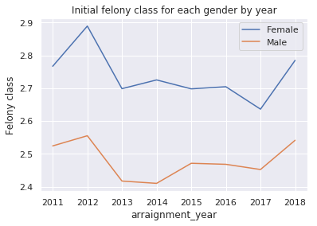

```python
by_gender.loc[:, :].plot()
plt.legend(bbox_to_anchor=(1, 1), loc='upper right',  ncol=1)
plt.ylabel('Felony class')
plt.title('Initial felony class for each gender by year')
plt.show()
```

# Part2: Exploring changes in felony class as defendants move from initiation through disposition. This entailed merging two data sets.

```python
disposition = pd.read_csv('Dispositions.csv', low_memory=False)
```

```python
disposition.head()
```

|  | CASE_ID | CASE_PARTICIPANT_ID | PRIMARY_CHARGE | CHARGE_ID | CHARGE_VERSION_ID | OFFENSE_TITLE | CHAPTER | ACT | SECTION | CLASS | ... | INCIDENT_BEGIN_DATE | INCIDENT_END_DATE | ARREST_DATE | LAW_ENFORCEMENT_AGENCY | UNIT | INCIDENT_CITY | RECEIVED_DATE | ARRAIGNMENT_DATE | UPDATED_OFFENSE_CATEGORY | CHARGE_COUNT |
| --- | --- | --- | --- | --- | --- | --- | --- | --- | --- | --- | --- | --- | --- | --- | --- | --- | --- | --- | --- | --- | --- |
| 0 | 61601638368 | 113580977306 | False | 82263540230 | 88097103639 | PROMIS Conversion | 38 | - | 9-1(a)(2) | X | ... | 8/9/1984 12:00:00 AM | NaN | 8/15/1984 12:00:00 AM | CHICAGO POLICE DEPT | NaN | NaN | 8/15/1984 12:00:00 AM | 9/21/1984 12:00:00 AM | Homicide | 2 |
| 1 | 61601638368 | 113580977306 | False | 82273775466 | 94780777269 | PROMIS Conversion | 38-33A-2\I | NaN | NaN | X | ... | 8/9/1984 12:00:00 AM | NaN | 8/15/1984 12:00:00 AM | CHICAGO POLICE DEPT | NaN | NaN | 8/15/1984 12:00:00 AM | 9/21/1984 12:00:00 AM | Homicide | 3 |
| 2 | 61601638368 | 113580977306 | False | 82273857348 | 99965682145 | PROMIS Conversion | 38 | - | 9-1(a)(3) | X | ... | 8/9/1984 12:00:00 AM | NaN | 8/15/1984 12:00:00 AM | CHICAGO POLICE DEPT | NaN | NaN | 8/15/1984 12:00:00 AM | 9/21/1984 12:00:00 AM | Homicide | 4 |
| 3 | 61601638368 | 113580977306 | False | 82273939230 | 99960728707 | PROMIS Conversion | 38 | - | 9-1(a)(3) | X | ... | 8/9/1984 12:00:00 AM | NaN | 8/15/1984 12:00:00 AM | CHICAGO POLICE DEPT | NaN | NaN | 8/15/1984 12:00:00 AM | 9/21/1984 12:00:00 AM | Homicide | 5 |
| 4 | 61601638368 | 113580977306 | False | 82274021112 | 99960940998 | PROMIS Conversion | 38 | - | 9-1(a)(3) | X | ... | 8/9/1984 12:00:00 AM | NaN | 8/15/1984 12:00:00 AM | CHICAGO POLICE DEPT | NaN | NaN | 8/15/1984 12:00:00 AM | 9/21/1984 12:00:00 AM | Homicide | 6 |

5 rows × 31 columns

```python
disposition.shape
```

```
(754945, 31)
```

```python
disposition.info()
```

```
<class 'pandas.core.frame.DataFrame'>
RangeIndex: 754945 entries, 0 to 754944
Data columns (total 31 columns):
CASE_ID                      754945 non-null int64
CASE_PARTICIPANT_ID          754945 non-null int64
PRIMARY_CHARGE               754945 non-null bool
CHARGE_ID                    754945 non-null int64
CHARGE_VERSION_ID            754945 non-null int64
OFFENSE_TITLE                754945 non-null object
CHAPTER                      754945 non-null object
ACT                          731840 non-null object
SECTION                      731840 non-null object
CLASS                        754786 non-null object
AOIC                         754764 non-null object
DISPO_DATE                   754945 non-null object
CHARGE_DISPOSITION           754945 non-null object
CHARGE_DISPOSITION_REASON    198178 non-null object
JUDGE                        692654 non-null object
COURT_NAME                   749526 non-null object
COURT_FACILITY               746748 non-null object
AGE_AT_INCIDENT              742462 non-null float64
GENDER                       752118 non-null object
RACE                         750971 non-null object
OFFENSE_TYPE                 754945 non-null object
INCIDENT_BEGIN_DATE          747988 non-null object
INCIDENT_END_DATE            87140 non-null object
ARREST_DATE                  739345 non-null object
LAW_ENFORCEMENT_AGENCY       753919 non-null object
UNIT                         232865 non-null object
INCIDENT_CITY                684307 non-null object
RECEIVED_DATE                754945 non-null object
ARRAIGNMENT_DATE             621943 non-null object
UPDATED_OFFENSE_CATEGORY     754945 non-null object
CHARGE_COUNT                 754945 non-null int64
dtypes: bool(1), float64(1), int64(5), object(24)
memory usage: 173.5+ MB
```

```python
merged = pd.merge(initiation, disposition, on=['CASE_PARTICIPANT_ID', 'CHARGE_ID'])
```

```python
merged.shape
```

```
(533522, 53)
```

```python
merged.head()
```

|  | CASE_ID_x | CASE_PARTICIPANT_ID | PRIMARY_CHARGE_x | CHARGE_ID | CHARGE_VERSION_ID_x | CHAPTER_x | ACT_x | SECTION_x | CLASS_x | AOIC_x | ... | INCIDENT_BEGIN_DATE_y | INCIDENT_END_DATE | ARREST_DATE_y | LAW_ENFORCEMENT_AGENCY_y | UNIT | INCIDENT_CITY_y | RECEIVED_DATE_y | ARRAIGNMENT_DATE_y | UPDATED_OFFENSE_CATEGORY_y | CHARGE_COUNT_y |
| --- | --- | --- | --- | --- | --- | --- | --- | --- | --- | --- | --- | --- | --- | --- | --- | --- | --- | --- | --- | --- | --- |
| 0 | 157303445894 | 459015687748 | False | 555449231356 | 480313281047 | 720 | 570 | 401(a)(2)(A) | X | 5095130 | ... | 12/15/2010 12:00:00 AM | NaN | 12/15/2010 8:40:00 PM | CHICAGO PD | NaN | Chicago | 1/31/2011 12:00:00 AM | 1/31/2011 12:00:00 AM | Narcotics | 2 |
| 1 | 157303445894 | 459015687748 | False | 556334538337 | 481092315287 | 720 | 5 | 24-1.7(a) | X | 0013855 | ... | 12/15/2010 12:00:00 AM | NaN | 12/15/2010 8:40:00 PM | CHICAGO PD | NaN | Chicago | 1/31/2011 12:00:00 AM | 1/31/2011 12:00:00 AM | Narcotics | 3 |
| 2 | 157303445894 | 459015687748 | False | 556335439038 | 481093093684 | 720 | 5 | 33A-2(a) | X | 0012372 | ... | 12/15/2010 12:00:00 AM | NaN | 12/15/2010 8:40:00 PM | CHICAGO PD | NaN | Chicago | 1/31/2011 12:00:00 AM | 1/31/2011 12:00:00 AM | Narcotics | 4 |
| 3 | 157303445894 | 459015687748 | False | 555347861578 | 480222703899 | 720 | 5 | 24-1.1(a) | 2 | 0012309 | ... | 12/15/2010 12:00:00 AM | NaN | 12/15/2010 8:40:00 PM | CHICAGO PD | NaN | Chicago | 1/31/2011 12:00:00 AM | 1/31/2011 12:00:00 AM | Narcotics | 5 |
| 4 | 157303445894 | 459015687748 | False | 556336339739 | 481093872082 | 720 | 5 | 24-1.6(a)(1) | 2 | 0012476 | ... | 12/15/2010 12:00:00 AM | NaN | 12/15/2010 8:40:00 PM | CHICAGO PD | NaN | Chicago | 1/31/2011 12:00:00 AM | 1/31/2011 12:00:00 AM | Narcotics | 6 |

5 rows × 53 columns

```python
merged_2 = merged[['CHARGE_ID', 'UPDATED_OFFENSE_CATEGORY_x',
                   'AGE_AT_INCIDENT_x','GENDER_x','RACE_x',
                   'ARREST_DATE_x','ARRAIGNMENT_DATE_x',
                   'DISPO_DATE','LAW_ENFORCEMENT_AGENCY_x',
                   'CLASS_x', 'CLASS_y', 'CHARGE_DISPOSITION']]
```

```python
merged_2.iloc[:,5:8].head(1)
```

|  | ARREST_DATE_x | ARRAIGNMENT_DATE_x | DISPO_DATE |
| --- | --- | --- | --- |
| 0 | 12/15/2010 8:40:00 PM | 1/31/2011 12:00:00 AM | 3/26/2012 12:00:00 AM |

```python
merged_2.iloc[:,5:8] = merged_2.iloc[:, 5:8].apply(pd.to_datetime, errors='coerce')
merged_2['arrest_year'] = merged_2.ARREST_DATE_x.dt.year
merged_2['arrest_month'] = merged_2.ARREST_DATE_x.dt.month
merged_2['arraignment_year'] = merged_2.ARRAIGNMENT_DATE_x.dt.year
merged_2['arraignment_month'] = merged_2.ARRAIGNMENT_DATE_x.dt.month
merged_2['disposition_year'] = merged_2.DISPO_DATE.dt.year
merged_2['disposition_month'] = merged_2.DISPO_DATE.dt.month
```

```python
merged_2.rename(columns={'UPDATED_OFFENSE_CATEGORY_x':'type_of_crime','AGE_AT_INCIDENT_x':'age',
                        'GENDER_x':'gender','RACE_x':'race', 'LAW_ENFORCEMENT_AGENCY_x':'law_enforcement_agency',
                        'CHARGE_DISPOSITION':'charge_disposition', 'CLASS_x':'felony_class_initiation',
                        'CLASS_y':'felony_class_disposition', 'ARREST_DATE_x':'arrest_date',
                        'ARRAIGNMENT_DATE_x':'arraignment_date','DISPO_DATE':'disposition_date'}, inplace=True)
```

```python
merged_2.head()
```

|  | CHARGE_ID | type_of_crime | age | gender | race | arrest_date | arraignment_date | disposition_date | law_enforcement_agency | felony_class_initiation | felony_class_disposition | charge_disposition | arrest_year | arrest_month | arraignment_year | arraignment_month | disposition_year | disposition_month |
| --- | --- | --- | --- | --- | --- | --- | --- | --- | --- | --- | --- | --- | --- | --- | --- | --- | --- | --- |
| 0 | 555449231356 | Narcotics | 34.0 | Male | Black | 2010-12-15 20:40:00 | 2011-01-31 | 2012-03-26 | CHICAGO PD | X | X | Finding Not Not Guilty | 2010 | 12 | 2011.0 | 1.0 | 2012.0 | 3.0 |
| 1 | 556334538337 | Narcotics | 34.0 | Male | Black | 2010-12-15 20:40:00 | 2011-01-31 | 2012-03-26 | CHICAGO PD | X | X | Finding Not Not Guilty | 2010 | 12 | 2011.0 | 1.0 | 2012.0 | 3.0 |
| 2 | 556335439038 | Narcotics | 34.0 | Male | Black | 2010-12-15 20:40:00 | 2011-01-31 | 2012-03-26 | CHICAGO PD | X | X | Finding Guilty | 2010 | 12 | 2011.0 | 1.0 | 2012.0 | 3.0 |
| 3 | 555347861578 | Narcotics | 34.0 | Male | Black | 2010-12-15 20:40:00 | 2011-01-31 | 2012-03-26 | CHICAGO PD | 2 | 2 | Finding Not Not Guilty | 2010 | 12 | 2011.0 | 1.0 | 2012.0 | 3.0 |
| 4 | 556336339739 | Narcotics | 34.0 | Male | Black | 2010-12-15 20:40:00 | 2011-01-31 | 2012-03-26 | CHICAGO PD | 2 | 2 | Finding Guilty | 2010 | 12 | 2011.0 | 1.0 | 2012.0 | 3.0 |

```python
merged_3 = merged_2[merged_2['felony_class_initiation'].isin(['X','1','2','3','4'])
                    & merged_2['felony_class_disposition'].isin(['X','1','2','3','4'])]
```

```python
merged_3 = merged_3[merged_3['gender'].isin(['Male','Female'])]
```

```python
merged_3.shape
```

```
(511726, 18)
```

In order to get a quantitative measure of changes in felony class as a defendant moved from initiation to disposition, I had to first convert the most serious class from the non-numeric X to the numeric 0. The other four felony classes were already in numeric form, ranging from 1 (the most serious after X) to 4 (the least serious). I then defined felony_class_difference as the change in felonly class value from initiation to dispositon. For example, a defendant moving from Class 0 to Class 3 would have a felony_class_difference of 3, while one moving from 2 to 3 would have felony_class_difference of 1.  
Note: there were some defendents whose felony class actually became more severe (e.g. moved from a 1 to a 0 or a 3 to 2). I did not include these in the analysis because their numbers were small and not very statistically meaningful. However, they might be worth investigating in a later analysis.

```python
merged_3['felony_class_initiation'] = merged_3['felony_class_initiation'].map({'X': 0,'1': 1,'2':2,'3':3, '4':4})
merged_3['felony_class_disposition'] = merged_3['felony_class_disposition'].map({'X': 0, '1': 1,'2':2,'3':3, '4':4})
```

```python
merged_3['felony_class_difference'] = merged_3['felony_class_disposition'] - merged_3['felony_class_initiation']
```

```python
merged_3['felony_class_difference'].value_counts()
```

```
 0    491818
 3      7052
 1      5813
 2      5081
 4      1859
-1        79
-2        16
-3         6
-4         2
Name: felony_class_difference, dtype: int64
```

```python
merged_3 = merged_3[merged_3['felony_class_difference'].isin([0,1,2,3,4])]
```

```python
merged_3.head()
```

|  | CHARGE_ID | type_of_crime | age | gender | race | arrest_date | arraignment_date | disposition_date | law_enforcement_agency | felony_class_initiation | felony_class_disposition | charge_disposition | arrest_year | arrest_month | arraignment_year | arraignment_month | disposition_year | disposition_month | felony_class_difference |
| --- | --- | --- | --- | --- | --- | --- | --- | --- | --- | --- | --- | --- | --- | --- | --- | --- | --- | --- | --- |
| 0 | 555449231356 | Narcotics | 34.0 | Male | Black | 2010-12-15 20:40:00 | 2011-01-31 | 2012-03-26 | CHICAGO PD | 0 | 0 | Finding Not Not Guilty | 2010 | 12 | 2011.0 | 1.0 | 2012.0 | 3.0 | 0 |
| 1 | 556334538337 | Narcotics | 34.0 | Male | Black | 2010-12-15 20:40:00 | 2011-01-31 | 2012-03-26 | CHICAGO PD | 0 | 0 | Finding Not Not Guilty | 2010 | 12 | 2011.0 | 1.0 | 2012.0 | 3.0 | 0 |
| 2 | 556335439038 | Narcotics | 34.0 | Male | Black | 2010-12-15 20:40:00 | 2011-01-31 | 2012-03-26 | CHICAGO PD | 0 | 0 | Finding Guilty | 2010 | 12 | 2011.0 | 1.0 | 2012.0 | 3.0 | 0 |
| 3 | 555347861578 | Narcotics | 34.0 | Male | Black | 2010-12-15 20:40:00 | 2011-01-31 | 2012-03-26 | CHICAGO PD | 2 | 2 | Finding Not Not Guilty | 2010 | 12 | 2011.0 | 1.0 | 2012.0 | 3.0 | 0 |
| 4 | 556336339739 | Narcotics | 34.0 | Male | Black | 2010-12-15 20:40:00 | 2011-01-31 | 2012-03-26 | CHICAGO PD | 2 | 2 | Finding Guilty | 2010 | 12 | 2011.0 | 1.0 | 2012.0 | 3.0 | 0 |

```python
merged_3.info()
```

```
<class 'pandas.core.frame.DataFrame'>
Int64Index: 511623 entries, 0 to 533521
Data columns (total 19 columns):
CHARGE_ID                   511623 non-null int64
type_of_crime               511623 non-null object
age                         511623 non-null float64
gender                      511623 non-null object
race                        511623 non-null object
arrest_date                 511623 non-null datetime64[ns]
arraignment_date            511620 non-null datetime64[ns]
disposition_date            511620 non-null datetime64[ns]
law_enforcement_agency      511623 non-null object
felony_class_initiation     511623 non-null int64
felony_class_disposition    511623 non-null int64
charge_disposition          511623 non-null object
arrest_year                 511623 non-null int64
arrest_month                511623 non-null int64
arraignment_year            511620 non-null float64
arraignment_month           511620 non-null float64
disposition_year            511620 non-null float64
disposition_month           511620 non-null float64
felony_class_difference     511623 non-null int64
dtypes: datetime64[ns](3), float64(5), int64(6), object(5)
memory usage: 78.1+ MB
```

```python
merged_3[['age','arraignment_year','disposition_year', 'arrest_year']]  = merged_3[['age','arraignment_year',
                                             'disposition_year', 'arrest_year']].fillna(0.0).astype(int)
```

```python
merged_3 = merged_3[(merged_3.arraignment_year < 2019) & (merged_3.arraignment_year > 2010) ]
```

```python
merged_3.arraignment_year.value_counts()
```

```
2012    80496
2013    77175
2014    69931
2011    68333
2015    67146
2016    63834
2017    56430
2018    27963
Name: arraignment_year, dtype: int64
```

```python
merged_3.race.value_counts()
```

```
Black                               345126
White [Hispanic or Latino]           90957
White                                62637
HISPANIC                              5562
Asian                                 3396
White/Black [Hispanic or Latino]      2571
Unknown                                712
American Indian                        275
Biracial                                66
ASIAN                                    6
Name: race, dtype: int64
```

```python
merged_3['race'] = merged_3['race'].str.lower()
```

```python
merged_3.race.value_counts()
```

```
black                               345126
white [hispanic or latino]           90957
white                                62637
hispanic                              5562
asian                                 3402
white/black [hispanic or latino]      2571
unknown                                712
american indian                        275
biracial                                66
Name: race, dtype: int64
```

```python
merged_3 = merged_3[merged_3['race'].isin(['black',
                    'white [hispanic or latino]',
                    'white', 'hispanic','asian',
                    'white/black [hispanic or latino]'])]
```

```python
grouped_by_race = merged_3.groupby(['arraignment_year', 'race']).felony_class_difference.mean()
grouped_by_race = grouped_by_race.unstack()
grouped_by_race
```

| race arraignment_year | asian | black | hispanic | white | white [hispanic or latino] | white/black [hispanic or latino] |
| --- | --- | --- | --- | --- | --- | --- |
| 2011 | 0.015113 | 0.079843 | 0.017949 | 0.026043 | 0.029219 | 0.068182 |
| 2012 | 0.020566 | 0.077486 | 0.001932 | 0.021830 | 0.023990 | 0.069164 |
| 2013 | 0.030992 | 0.096725 | 0.012277 | 0.037012 | 0.027868 | 0.097187 |
| 2014 | 0.030449 | 0.116887 | 0.005900 | 0.035701 | 0.032773 | 0.064407 |
| 2015 | 0.030744 | 0.142322 | 0.012563 | 0.045153 | 0.039002 | 0.083333 |
| 2016 | 0.041126 | 0.134739 | 0.008734 | 0.049277 | 0.048006 | 0.078035 |
| 2017 | 0.050505 | 0.138108 | 0.007843 | 0.048788 | 0.056300 | 0.111446 |
| 2018 | 0.068702 | 0.128518 | 0.000000 | 0.034443 | 0.059218 | 0.080357 |

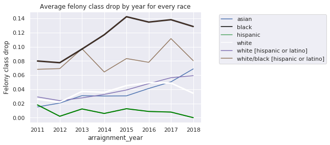

```python
grouped_by_race.loc[:, :].plot()
plt.legend(bbox_to_anchor=(1.75, 1), loc='upper right',  ncol=1)


plt.plot(grouped_by_race['black'], marker='', color='black', linewidth=3, alpha=0.7)
plt.plot(grouped_by_race['white'], marker='', color='white', linewidth=3, alpha=1)
plt.plot(grouped_by_race['hispanic'], marker='', color='green', linewidth=2, alpha=1)

ax = plt.gca()
leg = ax.get_legend()
leg.legendHandles[1].set_color('black')
leg.legendHandles[3].set_color('white')

plt.ylabel('Felony class drop')
plt.title('Average felony class drop by year for every race')
plt.show()
```

*Observations: Upon initial examination, one might think the system is biased towards Black people and against Hispanic people since the data shows Blacks and White/Black [Hispanic or Latino] having the largest average reductions in felony class from initiation to disposition and Hispanics having the least. However, this may in part be explained by the observation made in Part 1 above that Hispanics had much lower average felonly class averages at initiation than Black or White/Black [Hispanic or Latino} people. Since Hispanic defendants started with lesser charges, there was less room for them to move down during the plea bargain process. Asians were the one class that started out with among the most severe average charges yet had among the lowest average felony_class_drop of any of the racial groups. This does not prove bias, since it's possible that the circumstances of their individual cases could have warranted this, but it does suggest that further investigation may be warranted.*

```python
grouped_by_gender = merged_3.groupby(['arraignment_year', 'gender']).felony_class_difference.mean()
grouped_by_gender = grouped_by_gender.unstack()
```

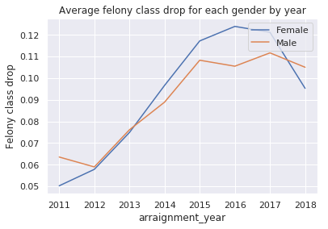

```python
grouped_by_gender.loc[:, :].plot()
plt.legend(bbox_to_anchor=(1, 1), loc='upper right',  ncol=1)
plt.ylabel('Felony class drop')
plt.title('Average felony class drop for each gender by year')
plt.show()
```

*Observations: In recent years except for 2018, Female defendants have enjoyed larger average felony_class_drops than their Male counterparts, and this is despite the observation made in Part 1 that Females began with much less serious initial charges. Again, this does not prove bias, but it does warrant further investigation.*

```python
merged_3.loc[merged_3['age'] <= 18, 'age'] = 0
merged_3.loc[(merged_3['age'] > 18) & (merged_3['age'] <= 25), 'age'] = 1
merged_3.loc[(merged_3['age'] > 25) & (merged_3['age'] <= 40), 'age'] = 2
merged_3.loc[(merged_3['age'] > 40) & (merged_3['age'] <= 55), 'age'] = 3
merged_3.loc[(merged_3['age'] > 55) & (merged_3['age'] <= 70), 'age'] = 4
merged_3.loc[merged_3['age'] > 70, 'age'] = 5
```

```python
grouped_by_age = merged_3.groupby(['arraignment_year', 'age']).felony_class_difference.mean()
grouped_by_age = grouped_by_age.unstack()
grouped_by_age
```

| age arraignment_year | 0 | 1 | 2 | 3 | 4 | 5 |
| --- | --- | --- | --- | --- | --- | --- |
| 2011 | 0.053636 | 0.059574 | 0.060310 | 0.078270 | 0.052632 | 0.000000 |
| 2012 | 0.051674 | 0.056595 | 0.051032 | 0.083463 | 0.060284 | 0.000000 |
| 2013 | 0.071000 | 0.072409 | 0.066203 | 0.101502 | 0.090263 | 0.023438 |
| 2014 | 0.083896 | 0.086009 | 0.076539 | 0.121615 | 0.103290 | 0.000000 |
| 2015 | 0.068809 | 0.092985 | 0.101746 | 0.150611 | 0.172367 | 0.025806 |
| 2016 | 0.107406 | 0.087014 | 0.092549 | 0.172261 | 0.150034 | 0.065934 |
| 2017 | 0.069473 | 0.084065 | 0.097985 | 0.192342 | 0.235955 | 0.082051 |
| 2018 | 0.062745 | 0.073789 | 0.091295 | 0.184997 | 0.202733 | 0.000000 |

*Seems like the most of the felony class drop occurs between the age 40 and 70, especially in recent years.*

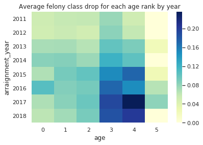

```python
ax = plt.axes()
sns.heatmap(grouped_by_age,cmap="YlGnBu")

ax.set_title('Average felony class drop for each age rank by year')
plt.show()
```

# Part 3: Analyzing types of crimes

```python
merged_3.head()
```

|  | CHARGE_ID | type_of_crime | age | gender | race | arrest_date | arraignment_date | disposition_date | law_enforcement_agency | felony_class_initiation | felony_class_disposition | charge_disposition | arrest_year | arrest_month | arraignment_year | arraignment_month | disposition_year | disposition_month | felony_class_difference |
| --- | --- | --- | --- | --- | --- | --- | --- | --- | --- | --- | --- | --- | --- | --- | --- | --- | --- | --- | --- |
| 0 | 555449231356 | Narcotics | 2 | Male | black | 2010-12-15 20:40:00 | 2011-01-31 | 2012-03-26 | CHICAGO PD | 0 | 0 | Finding Not Not Guilty | 2010 | 12 | 2011 | 1.0 | 2012 | 3.0 | 0 |
| 1 | 556334538337 | Narcotics | 2 | Male | black | 2010-12-15 20:40:00 | 2011-01-31 | 2012-03-26 | CHICAGO PD | 0 | 0 | Finding Not Not Guilty | 2010 | 12 | 2011 | 1.0 | 2012 | 3.0 | 0 |
| 2 | 556335439038 | Narcotics | 2 | Male | black | 2010-12-15 20:40:00 | 2011-01-31 | 2012-03-26 | CHICAGO PD | 0 | 0 | Finding Guilty | 2010 | 12 | 2011 | 1.0 | 2012 | 3.0 | 0 |
| 3 | 555347861578 | Narcotics | 2 | Male | black | 2010-12-15 20:40:00 | 2011-01-31 | 2012-03-26 | CHICAGO PD | 2 | 2 | Finding Not Not Guilty | 2010 | 12 | 2011 | 1.0 | 2012 | 3.0 | 0 |
| 4 | 556336339739 | Narcotics | 2 | Male | black | 2010-12-15 20:40:00 | 2011-01-31 | 2012-03-26 | CHICAGO PD | 2 | 2 | Finding Guilty | 2010 | 12 | 2011 | 1.0 | 2012 | 3.0 | 0 |

```python
merged_3['type_of_crime'].nunique()
```

```
78
```

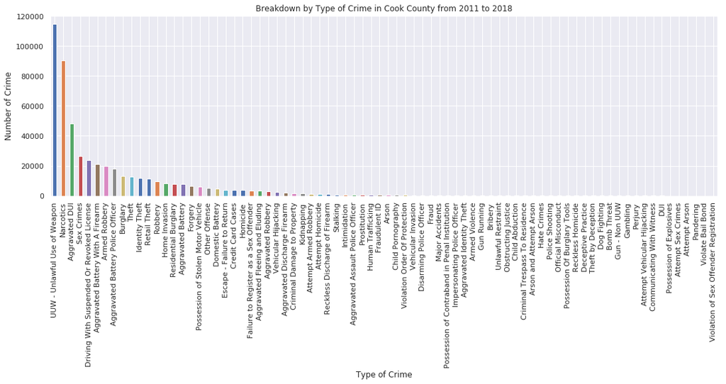

```python
f, ax = plt.subplots(figsize=(18,5))

ax = merged_3['type_of_crime'].value_counts().plot(kind='bar')
plt.title('Breakdown by Type of Crime in Cook County from 2011 to 2018')
plt.xlabel('Type of Crime')
plt.ylabel('Number of Crime')
```

```python
merged_4 = merged_3
```

```python
merged_4['felony_class_difference'] = merged_3.felony_class_difference.astype('object')
```

```python
merged_4 = merged_3[merged_3['felony_class_difference'].isin([1,2,3,4])]
```

```python
felony_charge_drop_by_race = pd.crosstab(index=merged_4['race'], columns=merged_4['felony_class_difference'], normalize='index')
felony_charge_drop_by_race
```

| felony_class_difference race | 1 | 2 | 3 | 4 |
| --- | --- | --- | --- | --- |
| asian | 0.548387 | 0.209677 | 0.161290 | 0.080645 |
| black | 0.246428 | 0.259128 | 0.391073 | 0.103370 |
| hispanic | 0.638889 | 0.250000 | 0.083333 | 0.027778 |
| white | 0.552053 | 0.258065 | 0.157625 | 0.032258 |
| white [hispanic or latino] | 0.499725 | 0.235036 | 0.206480 | 0.058759 |
| white/black [hispanic or latino] | 0.400000 | 0.170000 | 0.350000 | 0.080000 |

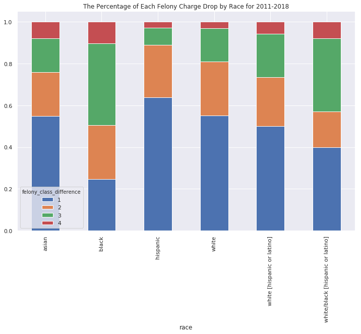

```python
felony_charge_drop_by_race.plot(kind="bar", figsize=(12,8), stacked=True)
plt.title('The Percentage of Each Felony Charge Drop by Race for 2011-2018')
plt.show()
```

```python
by_crime = merged_3[merged_3['type_of_crime'].isin(['UUW - Unlawful Use of Weapon',
                                        'Narcotics', 'Aggravated DUI', 'Sex Crimes',
                                        'Driving With Suspended Or Revoked License'])]
```

```python
by_crime = merged_3[merged_3['type_of_crime'].isin(['UUW - Unlawful Use of Weapon',
                                        'Narcotics', 'Aggravated DUI', 'Sex Crimes',
                                        'Driving With Suspended Or Revoked License'])]
```

*Below I made the table using the highest crime types' values and showed their percentage by each race.*

```python
crime_table = pd.crosstab(index=by_crime['race'], columns=by_crime['type_of_crime'],normalize='index')
crime_table
```

| type_of_crime race | Aggravated DUI | Driving With Suspended Or Revoked License | Narcotics | Sex Crimes | UUW - Unlawful Use of Weapon |
| --- | --- | --- | --- | --- | --- |
| asian | 0.182365 | 0.035404 | 0.308617 | 0.334669 | 0.138945 |
| black | 0.072519 | 0.072285 | 0.342414 | 0.048312 | 0.464469 |
| hispanic | 0.700340 | 0.149264 | 0.038505 | 0.027860 | 0.084032 |
| white | 0.286668 | 0.082454 | 0.337330 | 0.179335 | 0.114213 |
| white [hispanic or latino] | 0.344645 | 0.090591 | 0.146692 | 0.170394 | 0.247679 |
| white/black [hispanic or latino] | 0.133847 | 0.054660 | 0.280308 | 0.112824 | 0.418360 |

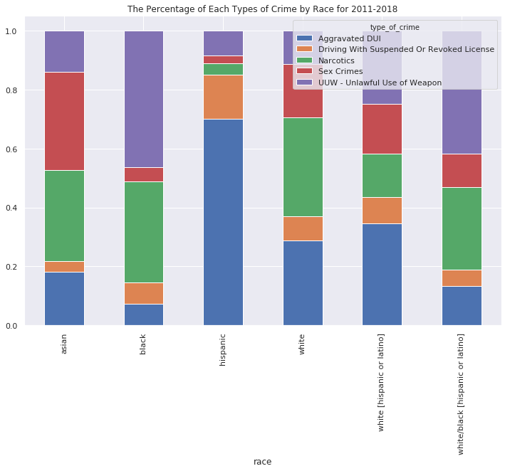

```python
crime_table.plot(kind="bar", figsize=(12,8), stacked=True)
plt.title('The Percentage of Each Types of Crime by Race for 2011-2018')
plt.show()
```

*Observations: It seems there is a similar pattern between Black and White/Black[Hispanic or Latino] peoples' crime types. Both races lead on UUW following by narcotics. Asian people have the highest record on Sex Crimes.*

# Idea for Further Improvements to Analysis

The aspect of the work done by the Cook County Attorney's Office that most impacts a defendant is what sentence that person ultimately receives at disposition. It would be very interesting to repeat the above analysis but replacing felony_class_difference as the dependent variable with something like "actual_sentence_versus_expectations", which I would define as follows:

1. find the average sentence given in Cook County for all defendants convicted of a given crime during the period (from 2011 to 2018, say) and call this the "expected_sentence".
2. add a column to the database that shows what sentence each defendant that plead guilty actually received at disposition. Call this the "actual_sentence". I am sure this data exists but wasn't sure where to find it.
3. for each defendant who took a plea bargain during the period, subtract the actual_sentence they received at disposition from the expected_sentence for the most serious crime they were charged with at initiation to get the actual_sentence_versus_expectations for that defendant.

After seeing the data, I may want to make some further analyses related to the above. For example, for defendants with multiple charges against them, it might also be interesting to add up the expected sentences for all the charges against them at initiation to get a "total_expected_sentence" at initiation, then compare this to the actual_sentence in the same manner. It might also be necessary to make some adjustments to the data to avoid distortions. For example, if a defendant is sentenced to multiple lifetimes, I might treat that as one lifetime of say 60 years or something since, in terms of what it actually means to a defendant, one lifetime is no different than 10 or a thousand.

1. I would then look at how the various independent variables (race, gender, age) affect the actual_sentence_versus_expectations.